# Shiny Application and Reproducible Pitch

2022-07-19

## Project Introduction

This peer assessed assignment has two parts. First, you will create a Shiny application and deploy it on Rstudio’s servers. Second, you will use Slidify or Rstudio Presenter to prepare a reproducible pitch presentation about your application.

1. Write a shiny application with associated supporting documentation. The documentation should be thought of as whatever a user will need to get started using your application.
2. Deploy the application on Rstudio’s shiny server
3. Share the application link by pasting it into the provided text box
4. Share your server.R and ui.R code on github

## How to use the application

It is a simple application help to view the number of telephones in various regions of the world (in thousands). You can just simply selecting the region and the trend of number of telephones through years will shown to you. The regions are: North America, Europe, Asia, South America, Oceania, Africa, Central America. The years are: 1951, 1956, 1957, 1958, 1959, 1960, 1961.

The application is running on [here](https://myitwb-yuan-li.shinyapps.io/MyShinyApp/)

To see theui.R, and Server.R Code, please visit my [github repository](https://github.com/YCherL/Course9-Developing-Data-Products)

## WorldPhones Dataset

The data used in the app comes from the WorldPhones dataset.

```r
library(datasets)
data(WorldPhones)
summary(WorldPhones)
```

```
##      N.Amer          Europe           Asia          S.Amer        Oceania
##  Min.   :45939   Min.   :21574   Min.   :2876   Min.   :1815   Min.   :1646
##  1st Qu.:62572   1st Qu.:31250   1st Qu.:4969   1st Qu.:2632   1st Qu.:2446
##  Median :68484   Median :35218   Median :6662   Median :2845   Median :2691
##  Mean   :66748   Mean   :34343   Mean   :6229   Mean   :2772   Mean   :2625
##  3rd Qu.:73918   3rd Qu.:38970   3rd Qu.:7538   3rd Qu.:3072   3rd Qu.:2961
##  Max.   :79831   Max.   :43173   Max.   :9053   Max.   :3338   Max.   :3224
##      Africa        Mid.Amer
##  Min.   :  89   Min.   : 555.0
##  1st Qu.:1478   1st Qu.: 753.0
##  Median :1663   Median : 836.0
##  Mean   :1484   Mean   : 841.7
##  3rd Qu.:1837   3rd Qu.: 959.5
##  Max.   :2005   Max.   :1076.0
```

```r
head(WorldPhones)
```

```
##      N.Amer Europe Asia S.Amer Oceania Africa Mid.Amer
## 1951  45939  21574 2876   1815    1646     89      555
## 1956  60423  29990 4708   2568    2366   1411      733
## 1957  64721  32510 5230   2695    2526   1546      773
## 1958  68484  35218 6662   2845    2691   1663      836
## 1959  71799  37598 6856   3000    2868   1769      911
## 1960  76036  40341 8220   3145    3054   1905     1008
```

## Number of Telephones in Asia

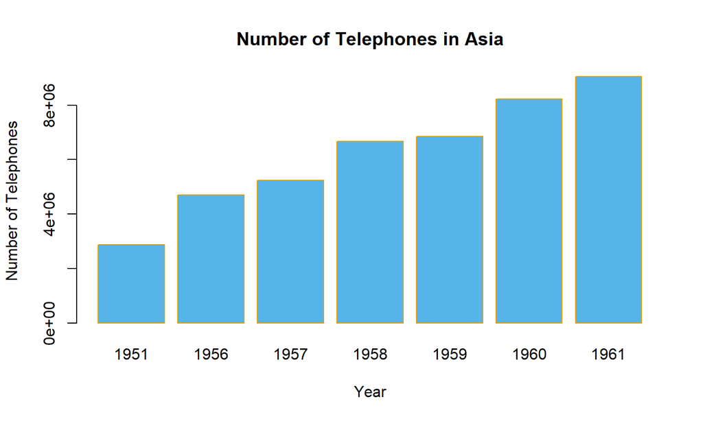